# Chapter 1: Data

## Key Ideas

Data, variables, values, class, logic, AND, OR, NOT, data frame, data set, feature, observation, histogram, scale, rescale, table, reshape, pivot, query

# Variables

The basic unit of **data** is the **variable**. We create variables and assign them values.

```r
var.number <- 1 #integers are descrete, decimals are continuous
var.logical <- TRUE
var.date <- as.Date("12/25/2018", "%m/%d/%Y")
var.vector <- c(1,2,3,4)
var.character <- "hello"
var.factor <- as.factor(var.vector)
```

After we create variables, we can access the variables by name and review their **values**

```r
var.number
```

```
[1] 1
```

```r
var.logical
```

```
[1] TRUE
```

```r
var.date
```

```
[1] "2018-12-25"
```

```r
var.vector
```

```
[1] 1 2 3 4
```

```r
var.character
```

```
[1] "hello"
```

```r
var.factor
```

```
[1] 1 2 3 4
Levels: 1 2 3 4
```

Each variable has a **class**. The variable class is determined by the data assigned to it at creation.

```r
#class type
class(var.number)
```

```
[1] "numeric"
```

```r
class(var.logical)
```

```
[1] "logical"
```

```r
class(var.date)
```

```
[1] "Date"
```

```r
class(var.vector)
```

```
[1] "numeric"
```

```r
class(var.character)
```

```
[1] "character"
```

```r
class(var.factor)
```

```
[1] "factor"
```

## Logic

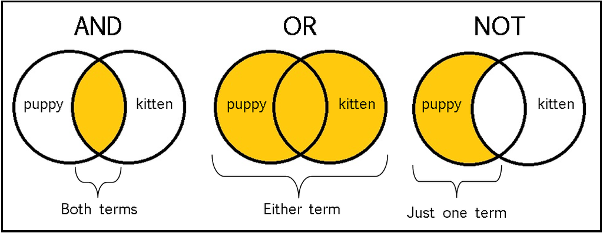

Source: historyinformationliteracy.wordpress.com

```r
socrates.mortal <- TRUE
socrates.immortal <- FALSE
socrates.mortalANDimmortal <- socrates.mortal && socrates.immortal
socrates.mortalANDimmortal
```

```
[1] FALSE
```

```r
socrates.mortalORimmortal <- socrates.mortal || socrates.immortal
socrates.mortalORimmortal
```

```
[1] TRUE
```

```r
if (socrates.mortalANDimmortal){
  print("That's impossible!")
} else {
  print("No one is both mortal and immortal")
}
```

```
[1] "No one is both mortal and immortal"
```

## Data Frames

A **data frame** is fundamental entity in data science. It’s the same as data you are used to seeing in a comma separated file (CSV) or an Excel spreadsheet. The primary representation of a **dataset** is a data frame.

```r
df <- as.data.frame(airquality)
df[1:5,]
```

```
  Ozone Solar.R Wind Temp Month Day
1    41     190  7.4   67     5   1
2    36     118  8.0   72     5   2
3    12     149 12.6   74     5   3
4    18     313 11.5   62     5   4
5    NA      NA 14.3   56     5   5
```

A **feature** is any column in the data frame.

```r
df$Temp[1:5]
```

```
[1] 67 72 74 62 56
```

An **observation** is any row from the data frame. For example, the 4th observation corresponds to the vector in the 4th row of the data frame.

```r
n=3
df[n,]
```

```
  Ozone Solar.R Wind Temp Month Day
3    12     149 12.6   74     5   3
```

Sometimes, observations have missing values.

```r
df.missingvalues <- df[rowSums(is.na(df)) > 0,]
df.missingvalues[1:5,]
```

```
   Ozone Solar.R Wind Temp Month Day
5     NA      NA 14.3   56     5   5
6     28      NA 14.9   66     5   6
10    NA     194  8.6   69     5  10
11     7      NA  6.9   74     5  11
25    NA      66 16.6   57     5  25
```

We can refer to a feature by number. For example the 4th feature of our dataset is the temperature feature.

```r
k=4
df[,k]
```

```
  [1] 67 72 74 62 56 66 65 59 61 69 74 69 66 68 58 64 66 57 68 62 59 73 61 61 57 58 57
 [28] 67 81 79 76 78 74 67 84 85 79 82 87 90 87 93 92 82 80 79 77 72 65 73 76 77 76 76
 [55] 76 75 78 73 80 77 83 84 85 81 84 83 83 88 92 92 89 82 73 81 91 80 81 82 84 87 85
 [82] 74 81 82 86 85 82 86 88 86 83 81 81 81 82 86 85 87 89 90 90 92 86 86 82 80 79 77
[109] 79 76 78 78 77 72 75 79 81 86 88 97 94 96 94 91 92 93 93 87 84 80 78 75 73 81 76
[136] 77 71 71 78 67 76 68 82 64 71 81 69 63 70 77 75 76 68
```

The 4th feature of the 3rd observation is a specific temperature: 74 degrees.

```r
df[n,k]
```

```
[1] 74
```

A **distribution** describes how often particular values of a feature occur. The following **histogram** shows the distribution of the temperature feature. The values of the temperature feature range from 50 degrees to 100 degrees. Most often, we see temperatures between 75 degrees and 85 degrees.

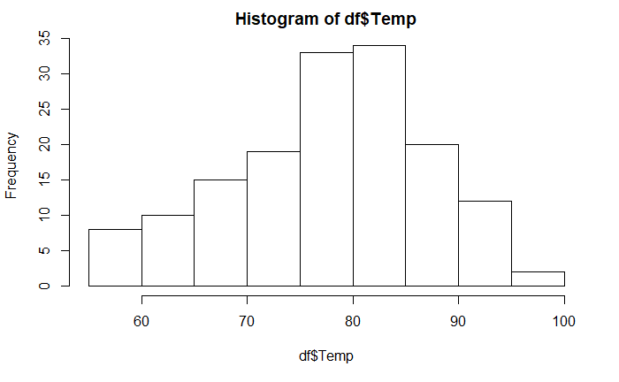

```r
hist(df$Temp)
```

The temperature feature is on a **scale** of 50 degrees to 100 degrees, but we can **rescale** the temperature feature so that the values range from, for example, 0 to 1.

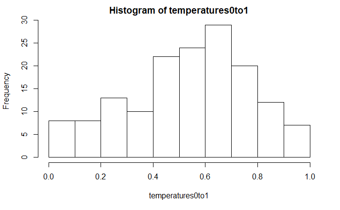

```r
#function to check if a package is installed
is_installed <- function(mypkg) is.element(mypkg, installed.packages()[,1])
#install and include the scales package
if(!is_installed("scales")){install.packages("scales")}
library(scales)
#rescale the temperature values
zero.to.one <- c(0,1)
temperatures0to1 <- rescale(df$Temp, zero.to.one)
#use a histogram to see the new scale of the temperature values
hist(temperatures0to1)
```

We can take the features from a data set and use them to create a **table.** For example, the following data set shows the survey results of smoking habits.

```r
#install and include the required package(s)
if(!is_installed("MASS")){install.packages("MASS")}
library("MASS")
df.survey <- as.data.frame(survey)
df.survey[1:5,]
```

```
     Sex Wr.Hnd NW.Hnd W.Hnd    Fold Pulse    Clap Exer Smoke Height      M.I    Age
1 Female   18.5   18.0 Right  R on L    92    Left Some Never  173.0   Metric 18.250
2   Male   19.5   20.5  Left  R on L   104    Left None Regul  177.8 Imperial 17.583
3   Male   18.0   13.3 Right  L on R    87 Neither None Occas     NA     <NA> 16.917
4   Male   18.8   18.9 Right  R on L    NA Neither None Never  160.0   Metric 20.333
5   Male   20.0   20.0 Right Neither    35   Right Some Never  165.0   Metric 23.667
```

We can create a table that shows smoking habits by sex (male or female). The following table shows the number of heavy smokers, occasional smokers, etc, broken down by female and male.

```r
survey.table <- table(df.survey$Smoke, df.survey$Sex)
survey.table
```

```
        Female Male
  Heavy      5    6
  Never     99   89
  Occas      9   10
  Regul      5   12
```

We can **reshape** a data set so that the observations and features are different. Take, for example a data set that shows observations of Titanic survivors.

```r
df.titanic <- as.data.frame(Titanic)
df.titanic[1:5,]
```

```
  Class    Sex   Age Survived Freq
1   1st   Male Child       No    0
2   2nd   Male Child       No    0
3   3rd   Male Child       No   35
4  Crew   Male Child       No    0
5   1st Female Child       No    0
```

```r
#install and include the reshape package
if(!is_installed("reshape")){install.packages("reshape")}
library(reshape)
df.titanic.pivot <- cast(df.titanic, Sex~Age, sum, value = "Freq")
df.titanic.pivot
```

```
     Sex Child Adult
1   Male    64  1667
2 Female    45   425
```

```r
conditions = (df.titanic$Sex=='Female' & df.titanic$Age=='Child')
df.titanic.filtered <- df.titanic[conditions,]
df.titanic.filtered
```

```
   Class    Sex   Age Survived Freq
5    1st Female Child       No    0
6    2nd Female Child       No    0
7    3rd Female Child       No   17
8   Crew Female Child       No    0
21   1st Female Child      Yes    1
22   2nd Female Child      Yes   13
23   3rd Female Child      Yes   14
24  Crew Female Child      Yes    0
```